# Credit Scoring

https://gist.github.com/Bart6114/8675941#file-creditset-csv

Credit scoring is the practice of analysing a persons background and credit application in order to assess the creditworthiness of the person. One can take numerous approaches on analysing this creditworthiness. In the end it basically comes down to first selecting the correct independent variables (e.g. income, age, gender) that lead to a given level of creditworthiness. In other words: creditworthiness=f(income, age, gender, …). A creditscoring system can be represented by linear regression, logistic regression, machine learning or a combination of these. Neural networks are situated in the domain of machine learining. The following is an strongly simplified example. The actual procedure of building a credit scoring system is much more complex and the resulting model will most likely not consist of solely or even a neural network.

If you’re unsure on what a neural network exactly is, I find this a good place to start.

For this example the R package neuralnet is used, for a more in-depth view on the exact workings of the package see neuralnet: Training of Neural Networks by F. Günther and S. Fritsch.

## load the data

```r
set.seed(1234567890)

library("neuralnet")

dataset <- read.csv("../data/creditset.csv")
head(dataset)
```

```
  clientid   income      age      loan          LTI default10yr
1        1 66155.93 59.01702 8106.5321 0.1225367512           0
2        2 34415.15 48.11715 6564.7450 0.1907515807           0
3        3 57317.17 63.10805 8020.9533 0.1399397997           0
4        4 42709.53 45.75197 6103.6423 0.1429105321           0
5        5 66952.69 18.58434 8770.0992 0.1309895000           1
6        6 24904.06 57.47161   15.4986 0.0006223321           0
```

## Objective

The dataset contains information on different clients who received a loan at least 10 years ago. The variables income (yearly), age, loan (size in euros) and LTI (the loan to yearly income ratio) are available. Our goal is to devise a model which predicts, based on the input variables LTI and age, whether or not a default will occur within 10 years.

## Steps

The dataset will be split up in a subset used for training the neural network and another set used for testing. As the ordering of the dataset is completely random, we do not have to extract random rows and can just take the first x rows.

```r
## extract a set to train the NN
trainset <- dataset[1:800, ]

## select the test set
testset <- dataset[801:2000, ]
```

### Build the neural network

Now we’ll build a neural network with 4 hidden nodes (a neural network is comprised of a input, hidden and output nodes). The number of nodes is chosen here without a clear method, however there are some rules of thumb. The lifesign option refers to the verbosity. The ouput is not linear and we will use a threshold value of 10%. The neuralnet package uses resilient backpropagation with weight backtracking as its standard algorithm.

```r
## build the neural network (NN)
creditnet <- neuralnet(default10yr ~ LTI + age, trainset, hidden = 4,
                       lifesign = "minimal",
                       linear.output = FALSE, threshold = 0.1)
```

```
hidden: 4    thresh: 0.1    rep: 1/1    steps:    7266  error: 0.79202  time: 2.15 secs
```

The neuralnet package also has the possibility to visualize the generated model and show the found weights.

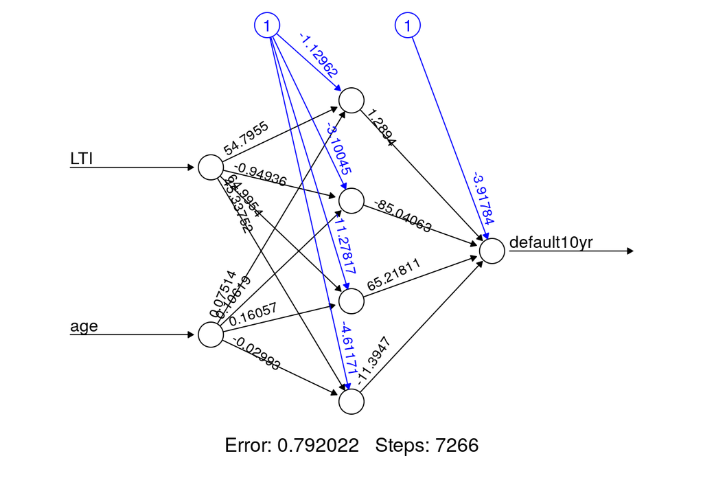

```r
## plot the NN
plot(creditnet, rep = "best")
```

## Test the neural network

Once we’ve trained the neural network we are ready to test it. We use the testset subset for this. The compute function is applied for computing the outputs based on the LTI and age inputs from the testset.

```r
## test the resulting output
temp_test <- subset(testset, select = c("LTI", "age"))

creditnet.results <- compute(creditnet, temp_test)
```

```r
head(temp_test)
```

```
              LTI         age
801 0.02306808811 25.90644520
802 0.13729704954 40.77430558
803 0.10456984914 32.47350580
804 0.15985046411 53.22813215
805 0.11161429579 46.47915325
806 0.11489364221 47.12736998
```

Let’s have a look at what the neural network produced:

```r
results <- data.frame(actual = testset$default10yr, prediction = creditnet.results$net.result)
results[100:115, ]
```

```
    actual                                 prediction
900      0 0.0000000000000000000000000015964854322398
901      0 0.0000000000000000000000000065162871249459
902      0 0.0000000000164043993271687111256424793281
903      1 0.9999999999219191249011373656685464084148
904      0 0.0000000000000000013810778585990260813531
905      0 0.0000000000000000539636283549265018968670
906      0 0.0000000000000000000234592312583961467191
907      1 0.9581419934268180504943757114233449101448
908      0 0.2499229633059911748205195181071758270264
909      0 0.0000000000000007044361454974853363540903
910      0 0.0006082559674722665078380745562469655852
911      1 0.9999999878713862200285689141310285776854
912      0 0.0000000000000000000000000015562211243506
913      1 0.9999999993455563895849991240538656711578
914      0 0.0000000000000000000000000000003082538282
915      0 0.0000000019359618836433911460647268798149
```

We can round to the nearest integer to improve readability:

```r
results$prediction <- round(results$prediction)
results[100:115, ]
```

```
    actual prediction
900      0          0
901      0          0
902      0          0
903      1          1
904      0          0
905      0          0
906      0          0
907      1          1
908      0          0
909      0          0
910      0          0
911      1          1
912      0          0
913      1          1
914      0          0
915      0          0
```

As you can see it is pretty close! As already stated, this is a strongly simplified example. But it might serve as a basis for you to play around with your first neural network.